# Fitting Normal Distribution

coop711

2018-03-21

## Data

### Frequency Table

- 케틀레가 작성한 스코틀랜드 군인 5738명의 가슴둘레(인치) 분포표를 옮기면

```r
chest <- 33:48
freq <- c(3, 18, 81, 185, 420, 749, 1073, 1079, 934, 658, 370, 92, 50, 21, 4, 1)
data.frame(chest, freq)
```

```
##    chest freq
## 1     33    3
## 2     34   18
## 3     35   81
## 4     36  185
## 5     37  420
## 6     38  749
## 7     39 1073
## 8     40 1079
## 9     41  934
## 10    42  658
## 11    43  370
## 12    44   92
## 13    45   50
## 14    46   21
## 15    47    4
## 16    48    1
```

```r
# sapply(data.frame(chest, freq), typeof)
data.frame(Chest = chest, Freq = freq)
```

```
##    Chest Freq
## 1     33    3
## 2     34   18
## 3     35   81
## 4     36  185
## 5     37  420
## 6     38  749
## 7     39 1073
## 8     40 1079
## 9     41  934
## 10    42  658
## 11    43  370
## 12    44   92
## 13    45   50
## 14    46   21
## 15    47    4
## 16    48    1
```

```r
chest_table <- data.frame(Chest = chest, Freq = freq)
chest_table
```

```
##    Chest Freq
## 1     33    3
## 2     34   18
## 3     35   81
## 4     36  185
## 5     37  420
## 6     38  749
## 7     39 1073
## 8     40 1079
## 9     41  934
## 10    42  658
## 11    43  370
## 12    44   92
## 13    45   50
## 14    46   21
## 15    47    4
## 16    48    1
```

```r
str(chest_table)
```

```
## 'data.frame':    16 obs. of  2 variables:
##  $ Chest: int  33 34 35 36 37 38 39 40 41 42 ...
##  $ Freq : num  3 18 81 185 420 ...
```

#### Extract Parts of an Object

```r
chest_table$Freq
```

```
##  [1]    3   18   81  185  420  749 1073 1079  934  658  370   92   50   21
## [15]    4    1
```

```r
str(chest_table$Freq)
```

```
##  num [1:16] 3 18 81 185 420 ...
```

```r
chest_table[, 2]
```

```
##  [1]    3   18   81  185  420  749 1073 1079  934  658  370   92   50   21
## [15]    4    1
```

```r
str(chest_table[, 2])
```

```
##  num [1:16] 3 18 81 185 420 ...
```

```r
chest_table[, "Freq"]
```

```
##  [1]    3   18   81  185  420  749 1073 1079  934  658  370   92   50   21
## [15]    4    1
```

```r
str(chest_table[, "Freq"])
```

```
##  num [1:16] 3 18 81 185 420 ...
```

```r
chest_table["Freq"]
```

```
##    Freq
## 1     3
## 2    18
## 3    81
## 4   185
## 5   420
## 6   749
## 7  1073
## 8  1079
## 9   934
## 10  658
## 11  370
## 12   92
## 13   50
## 14   21
## 15    4
## 16    1
```

```r
str(chest_table["Freq"])
```

```
## 'data.frame':    16 obs. of  1 variable:
##  $ Freq: num  3 18 81 185 420 ...
```

```r
chest_table["Freq"]$Freq
```

```
##  [1]    3   18   81  185  420  749 1073 1079  934  658  370   92   50   21
## [15]    4    1
```

```r
str(chest_table["Freq"]$Freq)
```

```
##  num [1:16] 3 18 81 185 420 ...
```

```r
chest_table["Freq"][[1]]
```

```
##  [1]    3   18   81  185  420  749 1073 1079  934  658  370   92   50   21
## [15]    4    1
```

```r
str(chest_table["Freq"][[1]])
```

```
##  num [1:16] 3 18 81 185 420 ...
```

```r
chest_table[2]
```

```
##    Freq
## 1     3
## 2    18
## 3    81
## 4   185
## 5   420
## 6   749
## 7  1073
## 8  1079
## 9   934
## 10  658
## 11  370
## 12   92
## 13   50
## 14   21
## 15    4
## 16    1
```

```r
str(chest_table[2])
```

```
## 'data.frame':    16 obs. of  1 variable:
##  $ Freq: num  3 18 81 185 420 ...
```

```r
chest_table[2]$Freq
```

```
##  [1]    3   18   81  185  420  749 1073 1079  934  658  370   92   50   21
## [15]    4    1
```

```r
str(chest_table[2]$Freq)
```

```
##  num [1:16] 3 18 81 185 420 ...
```

```r
chest_table[2][[1]]
```

```
##  [1]    3   18   81  185  420  749 1073 1079  934  658  370   92   50   21
## [15]    4    1
```

```r
str(chest_table[2][[1]])
```

```
##  num [1:16] 3 18 81 185 420 ...
```

```r
chest_table[[2]]
```

```
##  [1]    3   18   81  185  420  749 1073 1079  934  658  370   92   50   21
## [15]    4    1
```

```r
str(chest_table[[2]])
```

```
##  num [1:16] 3 18 81 185 420 ...
```

- 33인치인 사람이 3명, 34인치인 사람이 18명 등으로 기록되어 있으나 이는 구간의 가운데로 이해하여야 함.

### Probability Histogram

- `barplot(height, ...)` 은 기본적으로 `height`만 주어지면 그릴 수 있음. 확률 히스토그램의 기둥 면적의 합은 1이므로, 각 기둥의 높이는 각 계급의 돗수를 전체 돗수, 5738명으로 나눠준 값임.

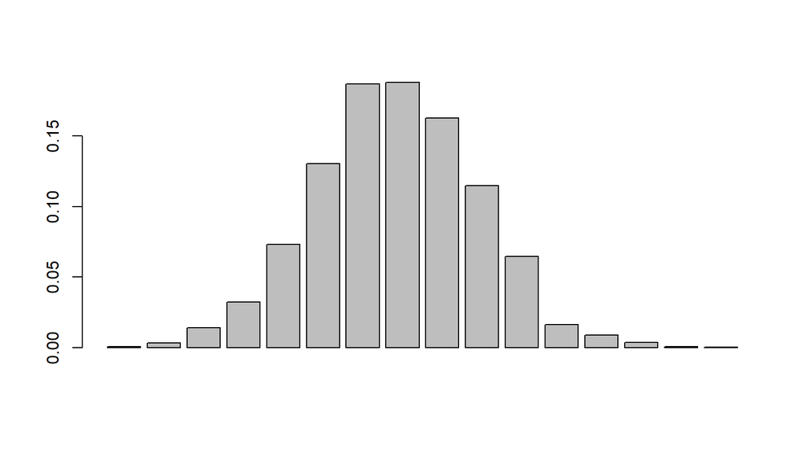

```r
total <- sum(chest_table$Freq)
barplot(chest_table$Freq/total)
```

- 각 막대의 이름은 계급을 나타내는 가슴둘레 값으로 표현할 수 있고, 막대 간의 사이를 띄우지 않으며, 디폴트 값으로 주어진 회색 보다는 차라리 백색이 나으므로 이를 설정해 주면,

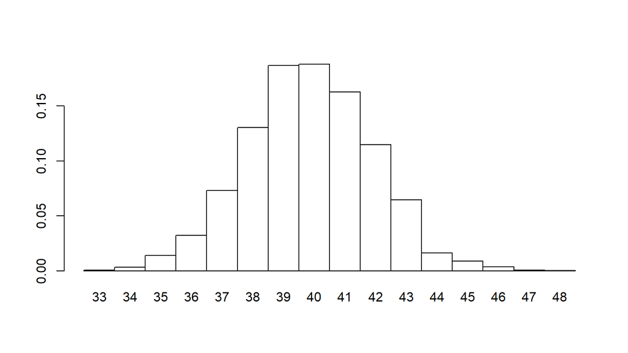

```r
barplot(chest_table$Freq/total,
        names.arg = 33:48,
        space = 0,
        col = "white")
```

- 확률 히스토그램의 정의에 따라 이 막대들의 면적을 합하면 1이 됨에 유의.

### Summary statistics and SD

- 33인치가 3명, 34인치가 18명 등을 한 줄의 긴 벡터로 나타내어야 평균과 표준편차를 쉽게 계산할 수 있으므로 long format으로 바꾸면,

```r
chest_long <- rep(chest_table$Chest, chest_table$Freq)
table(chest_long)
```

```
## chest_long
##   33   34   35   36   37   38   39   40   41   42   43   44   45   46   47
##    3   18   81  185  420  749 1073 1079  934  658  370   92   50   21    4
##   48
##    1
```

```r
str(chest_long)
```

```
##  int [1:5738] 33 33 33 34 34 34 34 34 34 34 ...
```

#### `rep()`

```r
rep(1:3, 3)
```

```
## [1] 1 2 3 1 2 3 1 2 3
```

```r
rep(1:3, each = 3)
```

```
## [1] 1 1 1 2 2 2 3 3 3
```

```r
rep(1:3, 1:3)
```

```
## [1] 1 2 2 3 3 3
```

- `chest_long` 을 이용하여 기초통계와 표준편차를 계산하면,

```r
summary(chest_long)
```

```
##    Min. 1st Qu.  Median    Mean 3rd Qu.    Max.
##   33.00   38.00   40.00   39.83   41.00   48.00
```

```r
sd(chest_long)
```

```
## [1] 2.049616
```

### Histogram

- 히스토그램을 직관적으로 그려보면 $y$축은 돗수가 기본값임을 알 수 있음.

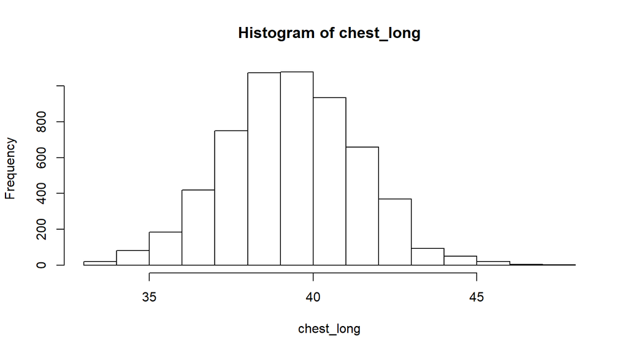

```r
hist(chest_long)
```

- 정규분포와 비교하기 위해서 $y$축을 확률로 나타내려면

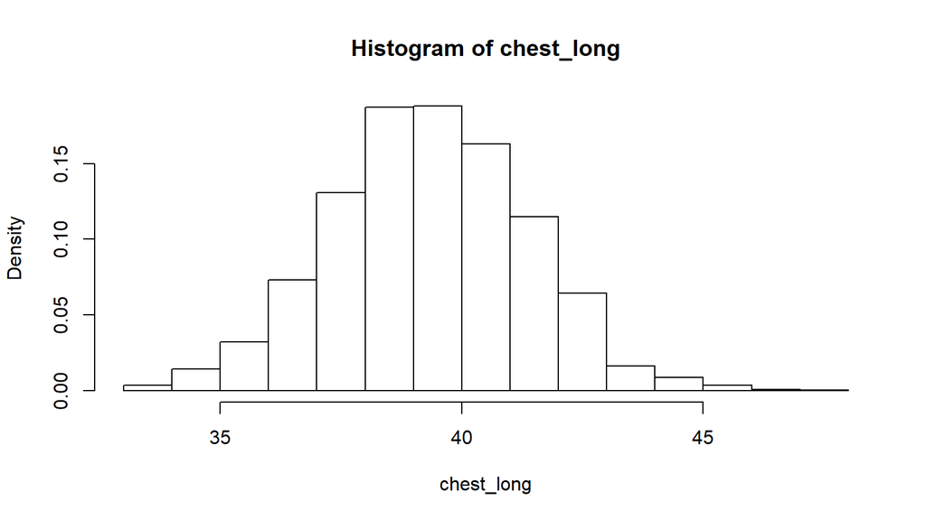

```r
hist(chest_long,
     probability = TRUE)
```

#### Inside the histogram

- 실제로 이 히스토그램을 그리는 데 계산된 값들은?

```r
(h_chest <- hist(chest_long,
                 plot = FALSE))
```

```
## $breaks
##  [1] 33 34 35 36 37 38 39 40 41 42 43 44 45 46 47 48
##
## $counts
##  [1]   21   81  185  420  749 1073 1079  934  658  370   92   50   21    4
## [15]    1
##
## $density
##  [1] 0.0036598118 0.0141164169 0.0322411990 0.0731962356 0.1305332869
##  [6] 0.1869989543 0.1880446148 0.1627744859 0.1146741025 0.0644823980
## [11] 0.0160334611 0.0087138376 0.0036598118 0.0006971070 0.0001742768
##
## $mids
##  [1] 33.5 34.5 35.5 36.5 37.5 38.5 39.5 40.5 41.5 42.5 43.5 44.5 45.5 46.5
## [15] 47.5
##
## $xname
## [1] "chest_long"
##
## $equidist
## [1] TRUE
##
## attr(,"class")
## [1] "histogram"
```

```r
list(breaks = h_chest$breaks,
     counts = h_chest$counts,
     density = h_chest$density,
     mids = h_chest$mids)
```

```
## $breaks
##  [1] 33 34 35 36 37 38 39 40 41 42 43 44 45 46 47 48
##
## $counts
##  [1]   21   81  185  420  749 1073 1079  934  658  370   92   50   21    4
## [15]    1
##
## $density
##  [1] 0.0036598118 0.0141164169 0.0322411990 0.0731962356 0.1305332869
##  [6] 0.1869989543 0.1880446148 0.1627744859 0.1146741025 0.0644823980
## [11] 0.0160334611 0.0087138376 0.0036598118 0.0006971070 0.0001742768
##
## $mids
##  [1] 33.5 34.5 35.5 36.5 37.5 38.5 39.5 40.5 41.5 42.5 43.5 44.5 45.5 46.5
## [15] 47.5
```

- 평균값과 표준편차로부터 히스토그램의 위치가 0.5만큼 왼쪽으로 치우쳐 있다는 것을 알 수 있음. 제자리에 옮겨 놓기 위해서 `breaks` 매개변수를 32.5부터 48.5까지 1간격으로 설정

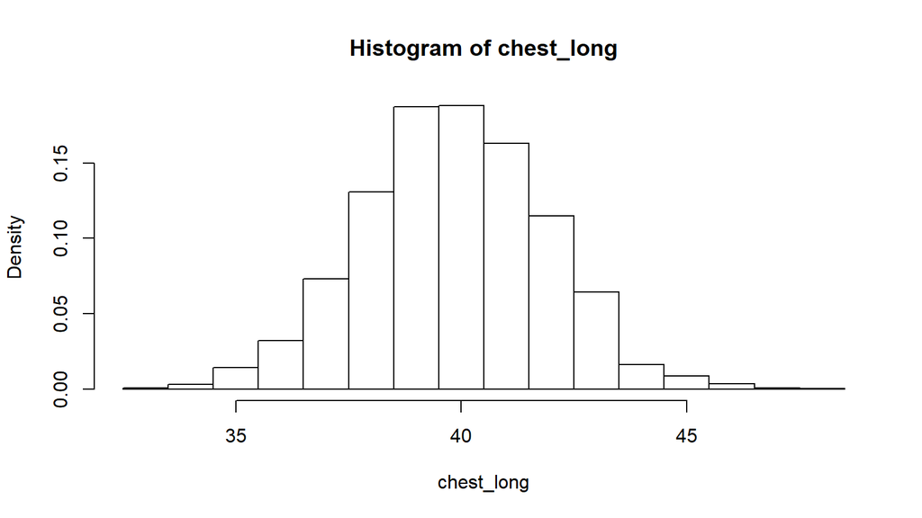

```r
hist(chest_long,
     probability = TRUE,
     breaks = 32.5:48.5)
```

- 위의 히스토그램을 그리느라고 계산된 값들은?

```r
h_chest.2 <- hist(chest_long,
                  breaks = 32.5:48.5,
                  plot = FALSE)
list(breaks = h_chest.2$breaks,
     counts = h_chest.2$counts,
     density = h_chest.2$density,
     mids = h_chest.2$mids)
```

```
## $breaks
##  [1] 32.5 33.5 34.5 35.5 36.5 37.5 38.5 39.5 40.5 41.5 42.5 43.5 44.5 45.5
## [15] 46.5 47.5 48.5
##
## $counts
##  [1]    3   18   81  185  420  749 1073 1079  934  658  370   92   50   21
## [15]    4    1
##
## $density
##  [1] 0.0005228303 0.0031369815 0.0141164169 0.0322411990 0.0731962356
##  [6] 0.1305332869 0.1869989543 0.1880446148 0.1627744859 0.1146741025
## [11] 0.0644823980 0.0160334611 0.0087138376 0.0036598118 0.0006971070
## [16] 0.0001742768
##
## $mids
##  [1] 33 34 35 36 37 38 39 40 41 42 43 44 45 46 47 48
```

- 히스토그램을 보기 쉽게 하기 위해서 메인 타이틀과 서브 타이틀, x축 라벨, y축 라벨 설정

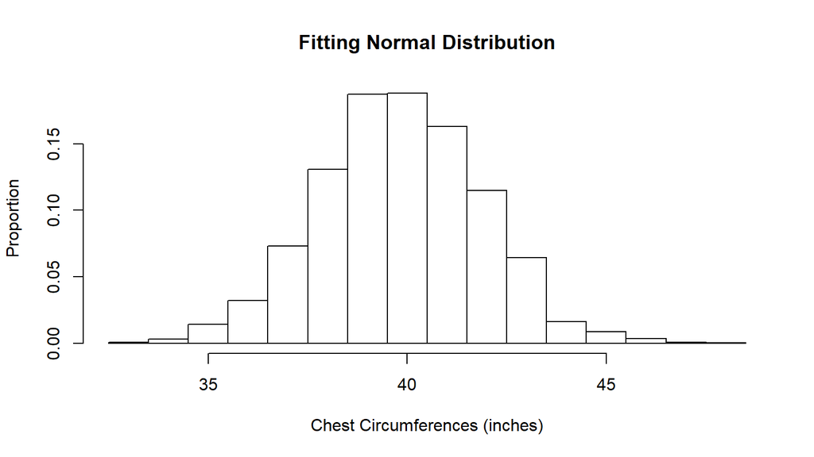

```r
main_title <- "Fitting Normal Distribution"
sub_title <- "Chest Circumferences of Scottish Soldiers"
sub_title <- ""
x_lab <- "Chest Circumferences (inches)"
y_lab <- "Proportion"
hist(chest_long,
     breaks = 32.5:48.5,
     probability = TRUE,
     main = main_title,
     sub = sub_title,
     xlab = x_lab,
     ylab = y_lab)
```

### Mean $\pm$ SD contains 2/3 of total number of counts

- 평균을 중심으로 $\pm$표준편차 만큼 떨어진 자료를 붉은 색 수직점선으로 표시.

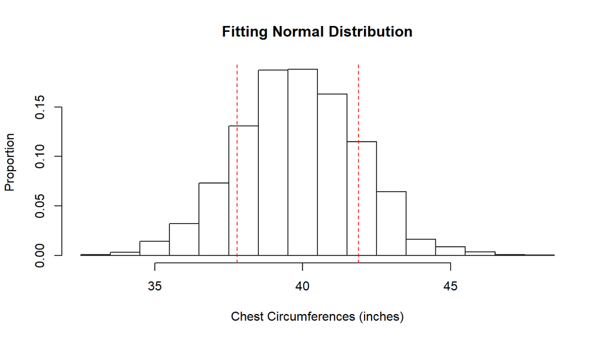

```r
mean_chest <- mean(chest_long)
sd_chest <- sd(chest_long)
x_lower <- mean_chest - sd_chest
x_upper <- mean_chest + sd_chest
hist(chest_long,
     breaks = 32.5:48.5,
     probability = TRUE,
     main = main_title,
     sub = sub_title,
     xlab = x_lab,
     ylab = y_lab)
abline(v = c(x_lower, x_upper),
       lty = 2,
       col = "red")
```

- 그 사이의 영역을 빗금으로 표시하기 위하여 다각형의 좌표를 계산

```r
h_chest.2$density[6:10]
```

```
## [1] 0.1305333 0.1869990 0.1880446 0.1627745 0.1146741
```

```r
y <- h_chest.2$density[6:10]
```

- 5개의 직사각형으로 파악하고 향후 면적 계산을 쉽게 하기 위하여 다음과 같이 좌표 설정

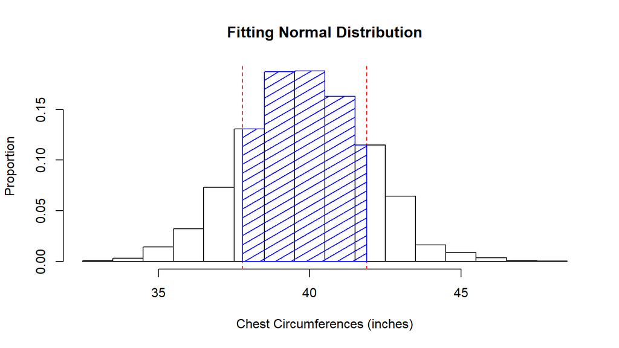

```r
x_coord <- rep(c(x_lower, 38.5:41.5,x_upper),  each = 2)
y_coord <- c(0, rep(y, each = 2), 0)
poly_df <- data.frame(x = x_coord,
                      y = y_coord)
hist(chest_long,
     breaks = 32.5:48.5,
     probability = TRUE,
     main = main_title,
     sub = sub_title,
     xlab = x_lab,
     ylab = y_lab)
abline(v = c(x_lower, x_upper),
       lty = 2,
       col = "red")
# polygon(x_coord, y_coord, density = 20)
polygon(poly_df,
        density = 10,
        angle = 30,
        col = "blue")
```

- 이론적으로 빗금친 부분의 면적은 `pnorm(1) - pnorm(-1) =`0.6826895에 가까울 것으로 예상. 5개 직사각형의 면적을 구하여 합하는 과정은 다음과 같음.

```r
options(digits = 2)
x_area <- c(x_lower, 38.5:41.5, x_upper)
y
```

```
## [1] 0.13 0.19 0.19 0.16 0.11
```

```r
diff(x_area)
```

```
## [1] 0.72 1.00 1.00 1.00 0.38
```

```r
diff(x_area) * y
```

```
## [1] 0.094 0.187 0.188 0.163 0.044
```

```r
sum(diff(x_area) * y)
```

```
## [1] 0.68
```

### Comparison with normal curve

- 이론적인 정규분포 밀도함수 곡선을 히스토그램에 덧붙여 그림.

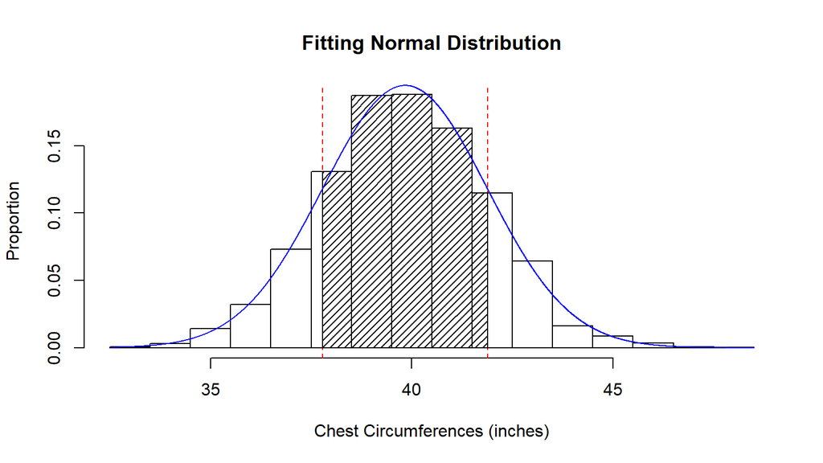

```r
x_chest <- seq(from = 32.5,
               to = 48.5,
#               by = 0.01,
#               length.out = 1000,
               along.with = chest_long)
# x_chest <- seq.along(chest_long)
y_norm <- dnorm(x_chest,
                mean = mean_chest,
                sd = sd_chest)
curve_df <- data.frame(x = x_chest,
                       y = y_norm)
hist(chest_long,
     breaks = 32.5:48.5,
     probability = TRUE,
     main = main_title,
     sub = sub_title,
     xlab = x_lab,
     ylab = y_lab)
abline(v = c(x_lower, x_upper),
       lty = 2,
       col = "red")
# abline(v = c(38, 42), lty = 2, col = "red")
polygon(poly_df,
        density = 20)
# polygon(x_coord, y_coord, density = 20)
# lines(x = x_chest,
#      y = y_norm,
#      col = "blue")
lines(curve_df,
      col = "blue")
```

### Changing tick marks of x axis

- default로 주어지는 $x$축의 눈금을 제대로 볼 수 있게 고치려면,

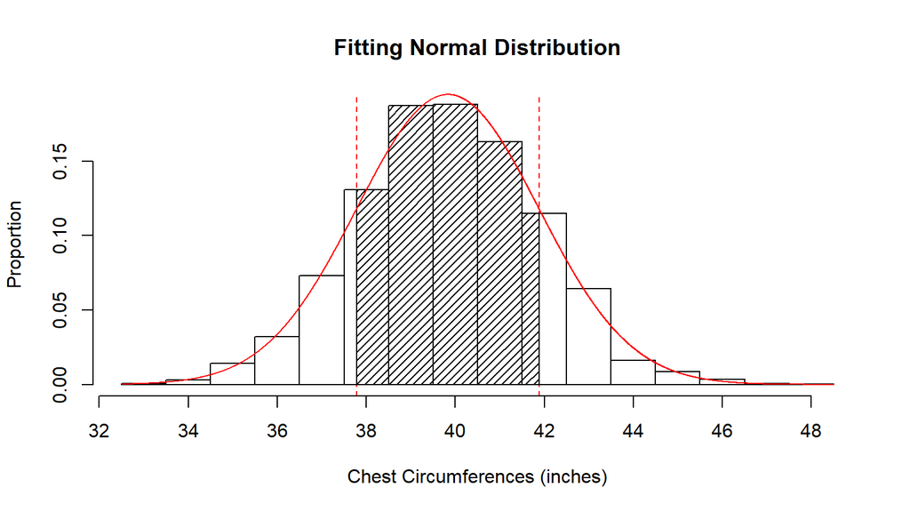

```r
hist(chest_long,
     breaks = 32.5:48.5,
     probability = TRUE,
     main = main_title,
     sub = sub_title,
     xlab = x_lab,
     ylab = y_lab,
     axes = FALSE)
abline(v = c(x_lower, x_upper),
       lty = 2,
       col = "red")
polygon(poly_df,
        density = 20)
# polygon(x_coord, y_coord, density = 20)
lines(curve_df,
      col = "red")
axis(side = 1,
     at = seq(32, 48, by = 2),
     labels = seq(32, 48, by = 2))
axis(side = 2)
```

### ggplot

- data frame으로 작업.

#### Basic histogram

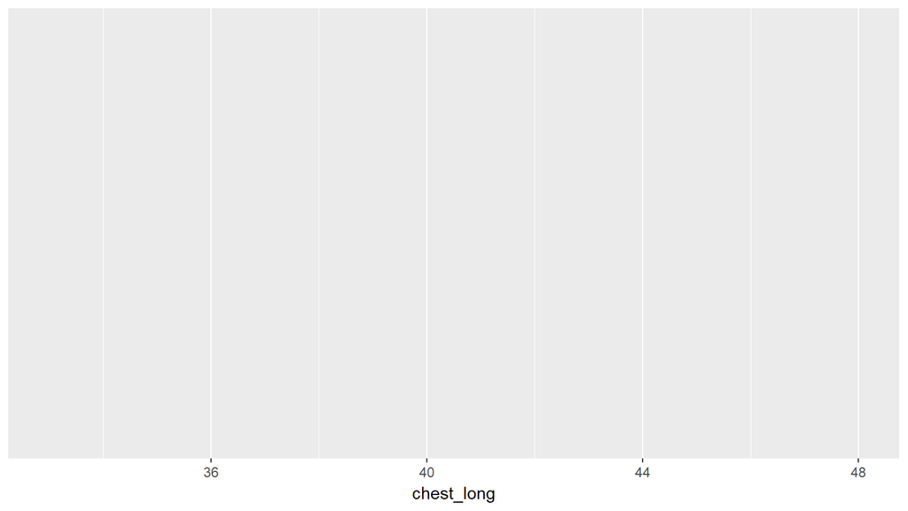

```r
library(ggplot2)
# theme_update(plot.title = element_text(hjust = 0.5))
g0 <- ggplot(data = data.frame(chest_long),
             mapping = aes(x = chest_long))
g0
```

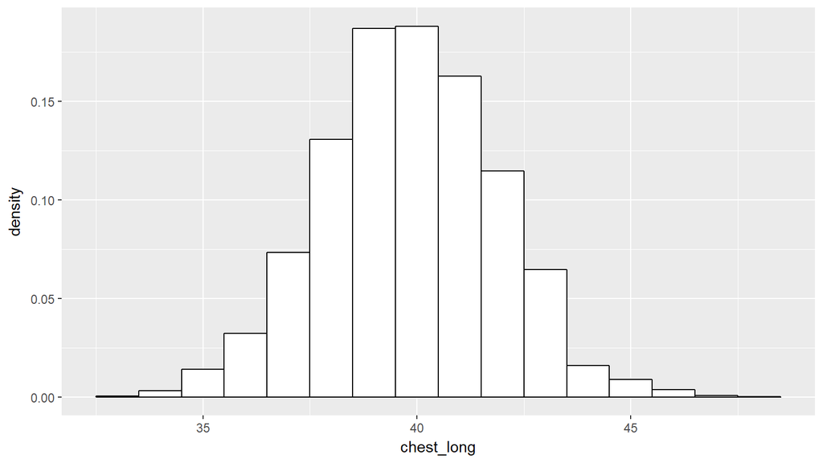

```r
# (g1 <- g0 +
#   stat_bin(aes(y = ..density..),
#            binwidth = 1,
#           fill = "white",
#           colour = "black"))
# (g1 <- g0 +
#     stat_count(fill = "white",
#                colour = "black"))
# (g1 <- g0 +
#   geom_histogram(aes(y = ..density..),
#                  binwidth = 1,
#                  fill = "white",
#                  colour = "black"))
(g1 <- g0 +
    geom_histogram(aes(y = ..density..),
                   binwidth = 1,
                   breaks = 32.5:48.5,
                   fill = "white",
                   colour = "black"))
```

```r
# g1
```

#### Mean $\pm$ SD

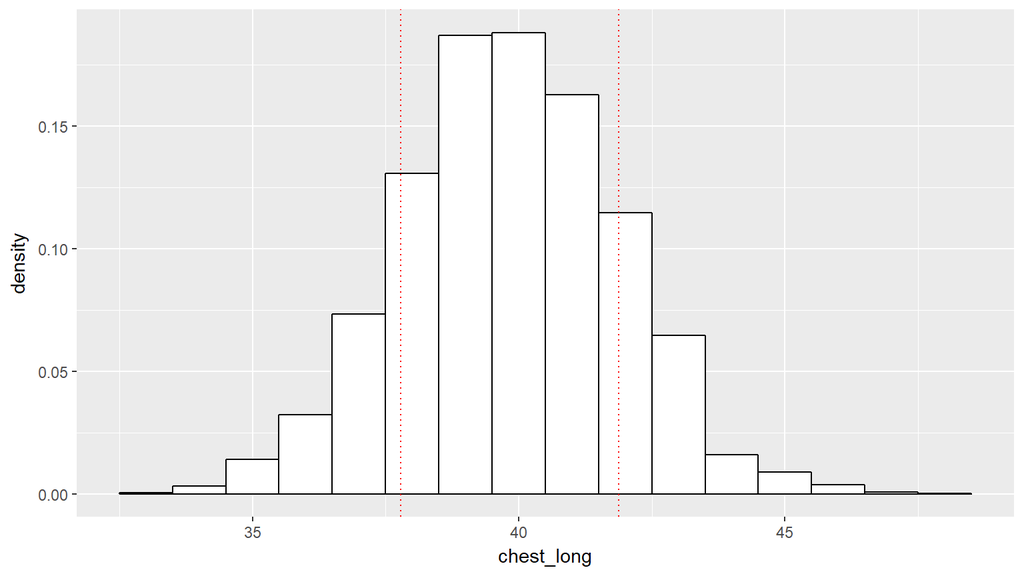

```r
(g2 <- g1 +
   geom_vline(xintercept = c(x_lower, x_upper),
              linetype = "dotted",
              colour = "red"))
```

#### x-axis label and main title

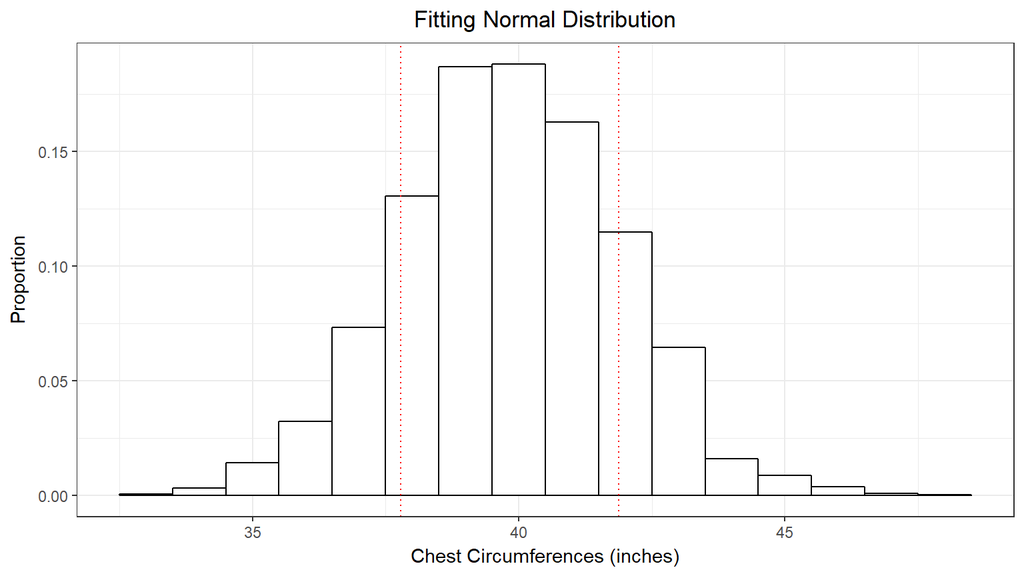

```r
(g3 <- g2 +
   theme_bw() +
#   xlab(x_lab) +
#   ylab(y_lab) +
#   ggtitle(main_title) +
   labs(x = x_lab,
        y = y_lab,
        title = main_title) +
  theme(plot.title = element_text(hjust = 0.5)))
```

#### Shading the area

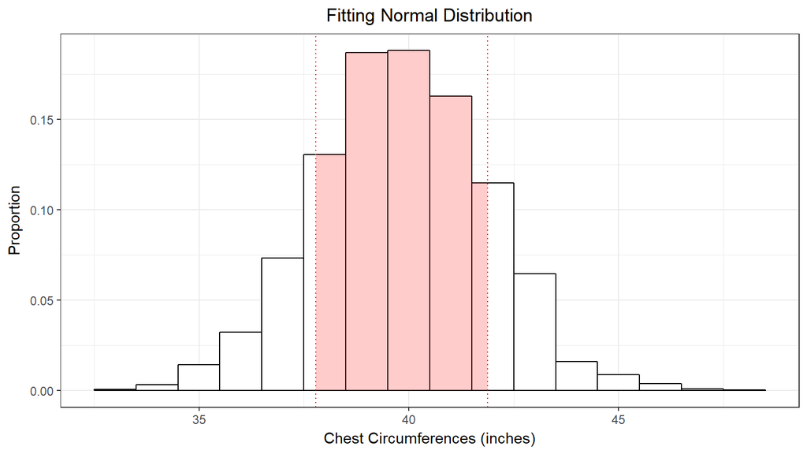

```r
(g4 <- g3 +
   geom_polygon(data = poly_df,
                mapping = aes(x = x, y = y),
                alpha = 0.2,
                fill = "red"))
```

#### Normal curve added

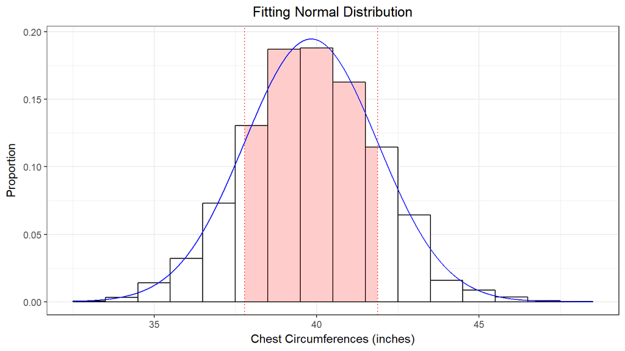

```r
(g5 <- g4 +
  geom_line(data = curve_df,
            mapping = aes(x = x, y = y),
            colour = "blue"))
```

#### x-axis tick marks

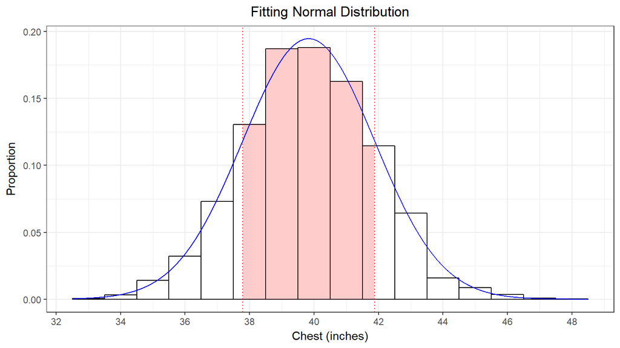

```r
(g6 <- g5 +
   scale_x_continuous(name = "Chest (inches)",
                      breaks = seq(32, 48, by = 2),
                      labels = seq(32, 48, by = 2)))
```

### Save

```r
# save(list = ls(), file = "./Quetelet_chest.RData")
save.image(file = "./Quetelet_chest.RData")
```